# Importing and Processing CSV Files

## Next Steps

I think you should evaluate every month and see what happens. You might also consider looking at the TMIN as well. Could be important!

## Lets try Dec

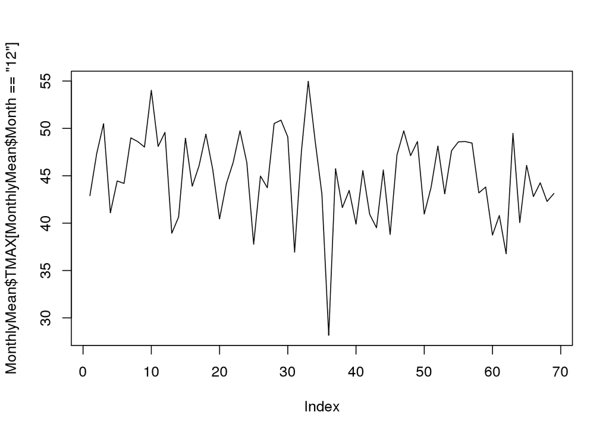

```r
plot(MonthlyMean$TMAX[MonthlyMean$Month=="12"], ty='l')
```

```r
plot(TMAX~YEAR, data=MonthlyMean[MonthlyMean$Month=="12",], ty='l')
Dec.lm <- lm(TMAX~YEAR, data=MonthlyMean[MonthlyMean$Month=="12",])
summary(Dec.lm)
```

```
##
## Call:
## lm(formula = TMAX ~ YEAR, data = MonthlyMean[MonthlyMean$Month ==
##     "12", ])
##
## Residuals:
##      Min       1Q   Median       3Q      Max
## -16.7132  -2.9056   0.3066   3.5902   9.9538
##
## Coefficients:
##              Estimate Std. Error t value Pr(>|t|)
## (Intercept) 137.07966   53.45562   2.564   0.0126 *
## YEAR         -0.04650    0.02697  -1.724   0.0893 .
## ---
## Signif. codes:  0 '***' 0.001 '**' 0.01 '*' 0.05 '.' 0.1 ' ' 1
##
## Residual standard error: 4.462 on 67 degrees of freedom
## Multiple R-squared:  0.04248,    Adjusted R-squared:  0.02819
## F-statistic: 2.973 on 1 and 67 DF,  p-value: 0.0893
```

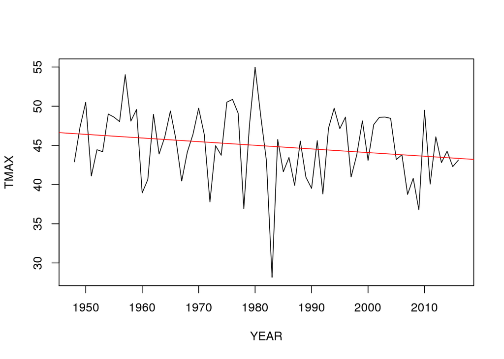

```r
abline(coef(Dec.lm), col="red")
```

## TMIN

1. We create a monthly mean for each month.

```r
MonthlyMeanTMIN = aggregate(TMIN ~ Month + Year, LosAngeles, mean)

MonthlyMeanTMIN$YEAR = as.numeric(MonthlyMeanTMIN$Year)
head(MonthlyMeanTMIN)
```

```
##   Month Year     TMIN YEAR
## 1    01 1948 12.25806 1948
## 2    02 1948 13.89655 1948
## 3    03 1948 17.48387 1948
## 4    04 1948 36.46667 1948
## 5    05 1948 44.87097 1948
## 6    06 1948 53.53333 1948
```

2. Now we plot the mins, and again, find tons of scatter.

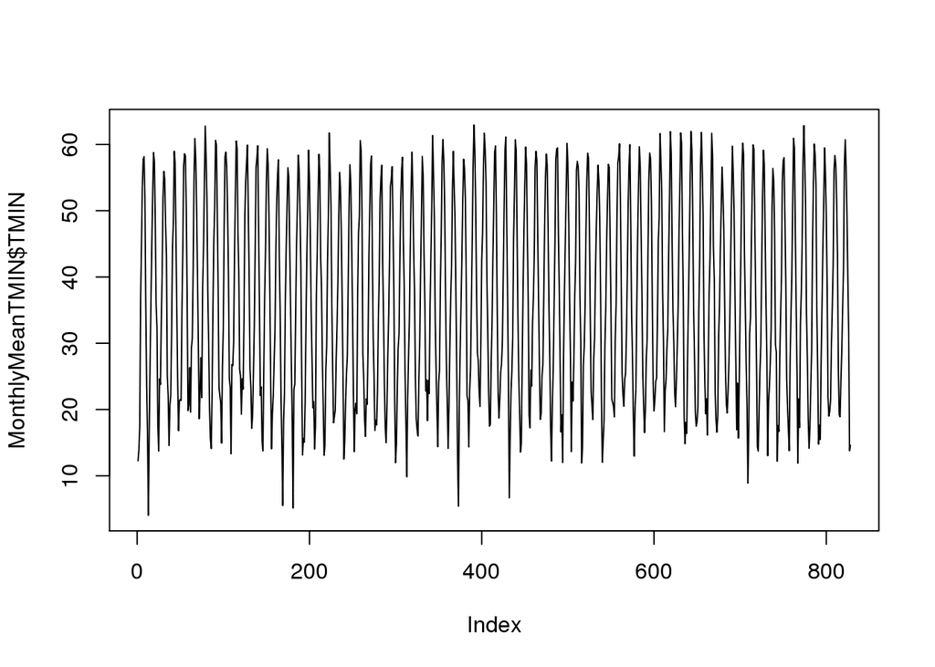

```r
plot(MonthlyMeanTMIN$TMIN, ty='l')
```

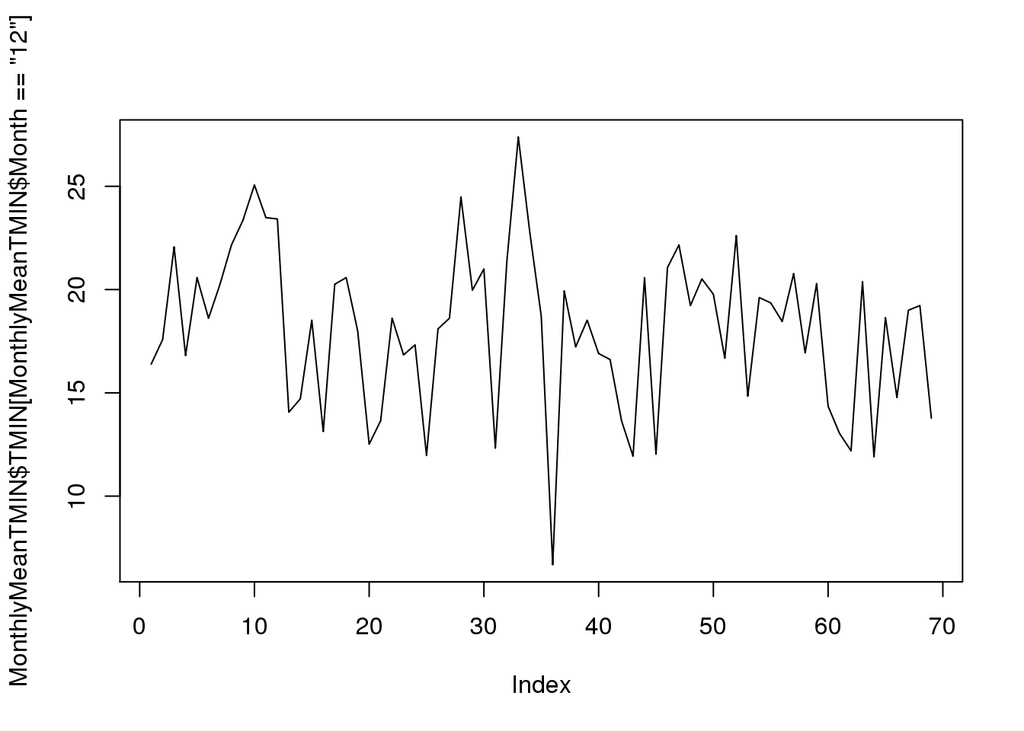

```r
plot(MonthlyMeanTMIN$TMIN[MonthlyMeanTMIN$Month=="12"], ty='l')
```

```r
plot(TMIN~YEAR, data=MonthlyMeanTMIN[MonthlyMeanTMIN$Month=="12",], ty='l')
Dec.lm <- lm(TMIN~YEAR, data=MonthlyMeanTMIN[MonthlyMeanTMIN$Month=="12",])
summary(Dec.lm)
```

```
##
## Call:
## lm(formula = TMIN ~ YEAR, data = MonthlyMeanTMIN[MonthlyMeanTMIN$Month ==
##     "12", ])
##
## Residuals:
##      Min       1Q   Median       3Q      Max
## -11.3757  -2.5678   0.5771   2.7561   9.2199
##
## Coefficients:
##             Estimate Std. Error t value Pr(>|t|)
## (Intercept) 93.48458   45.75093   2.043    0.045 *
## YEAR        -0.03804    0.02308  -1.648    0.104
## ---
## Signif. codes:  0 '***' 0.001 '**' 0.01 '*' 0.05 '.' 0.1 ' ' 1
##
## Residual standard error: 3.819 on 67 degrees of freedom
## Multiple R-squared:  0.03896,    Adjusted R-squared:  0.02461
## F-statistic: 2.716 on 1 and 67 DF,  p-value: 0.104
```

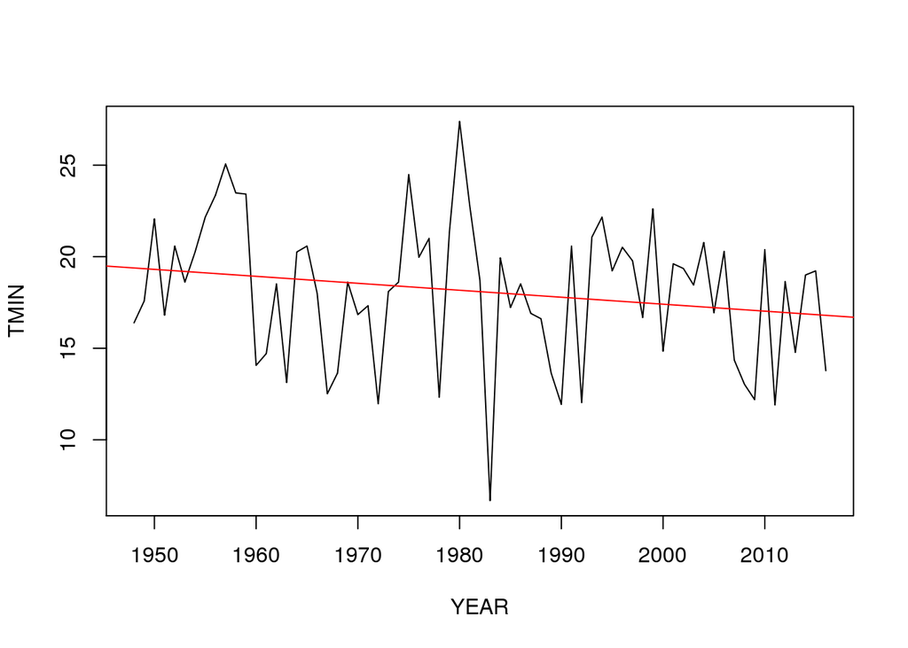

```r
abline(coef(Dec.lm), col="red")
```

# Departure from Mean

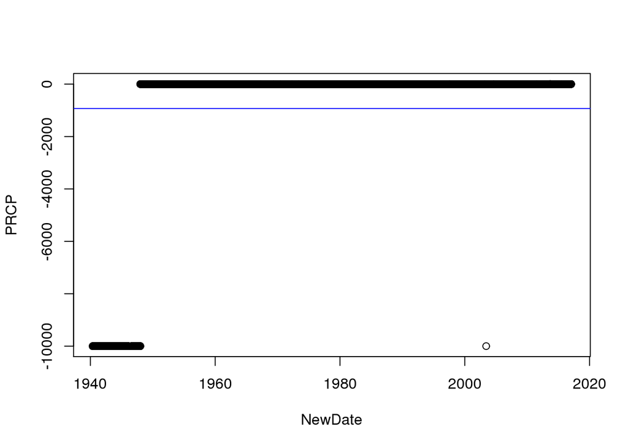

```r
PRCP_mean = mean(LosAngeles$PRCP, na.rm=T)

plot(PRCP~NewDate, data=LosAngeles)
abline(h=PRCP_mean, col="blue")
```

## Experimental Portion — Precipitation

Precipiation might depend more on the departure from the mean (often referred as as normal, whatever that means!). I think it’s worth pursuing, but haven’t finished the analysis yet.

First, we need a “mean” – The IPCC uses 1961-1990 as a norm, I don’t know what is the standard for California, so we should look that up.

Second, we need to remove the missing values and evalaute which years have complete years. If you are missing rainy months, then the whole year should be thrown out – but what about partial years in the drought season?

Third, we will need to decide what level of aggredation – monthly, yearly, etc.

Fourth, in CA the water year starts in Oct 1. Should we follow the same convention?

```r
LosAngeles$PRCP[LosAngeles$PRCP==-9999] <- NA
YearlySum = aggregate(PRCP ~ Year, LosAngeles, sum)
YearlySum$YEAR = as.numeric(YearlySum$Year)
YearlyMean = mean(YearlySum$PRCP)
```

A yearly mean, based on the annual sum for the entire records. Not sure this is appropriate.

Figure has points of the yearly sum of rainfall and the blue line mean. The greenline is the trend and red line is a five year running average, I think! I am still trying to understand what the code is doing.

```r
plot(PRCP~YEAR, data=YearlySum, las=1, ty="p")
abline(h=YearlyMean, col="blue")
YearlySum.lm = lm(PRCP~YEAR, data=YearlySum)
abline(coef(YearlySum.lm), col="green")

n <- 5
k <- rep(1/n, n)
k
```

```
## [1] 0.2 0.2 0.2 0.2 0.2
```

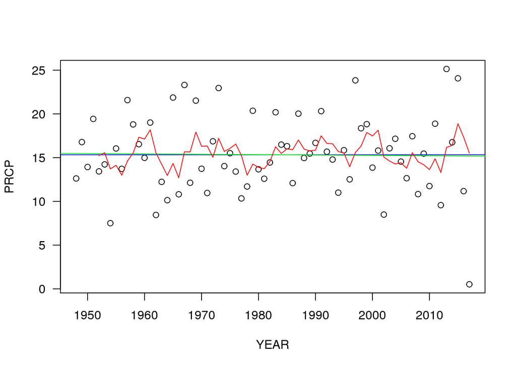

```r
y_lag <- stats::filter(YearlySum$PRCP, k, sides=1)
lines(YearlySum$YEAR, y_lag, col="red")
```

The model suggests that the precipitation is declines at a rate of -0.0043281 cm yr$^{-1}~$, or -0.04 cm decade$^{-1}$.

```r
summary(YearlySum.lm)
```

```
##
## Call:
## lm(formula = PRCP ~ YEAR, data = YearlySum)
##
## Residuals:
##      Min       1Q   Median       3Q      Max
## -14.6628  -2.8345  -0.1015   2.8772   9.9399
##
## Coefficients:
##              Estimate Std. Error t value Pr(>|t|)
## (Intercept) 23.912512  52.188748   0.458    0.648
## YEAR        -0.004328   0.026323  -0.164    0.870
##
## Residual standard error: 4.45 on 68 degrees of freedom
## Multiple R-squared:  0.0003974,  Adjusted R-squared:  -0.0143
## F-statistic: 0.02703 on 1 and 68 DF,  p-value: 0.8699
```

Other attempts that didn’t work!

```r
YearlySum2 = subset(YearlySum, select=c(PRCP))
YearlyMean = mean(YearlySum2$PRCP)

#filter(YearlySum2)



#Doesn't work...
# ma <- function(x,n=5){filter(x,rep(1/n,n), sides=2)}
# ma(YearlySum$PRCP)


yearlyts =ts(YearlySum2)
str(yearlyts)
```

```
##  Time-Series [1:70, 1] from 1 to 70: 12.6 16.8 13.9 19.4 13.4 ...
##  - attr(*, "dimnames")=List of 2
##   ..$ : NULL
##   ..$ : chr "PRCP"
```

yearlyts.lag = lag(yearlyts, 5)[6:112,]; head(yearlyts.lag)

plot(yearlyts, lty = 1, col = 3)

lines(yearlyts.lag)

lines(Departure ~ YEAR, data=YearlySum, col=“red”)